# EDAV-Project2

Team

February 18, 2016

# Introduction

For this report we will be diving into the global issue of Flood Events. The intial goal of the paper will be to investigate the datasets to better understand. The dataset being investigated involves geographical, spatial, and time parameters that creates an extremely large amount of information to be explored. We will work to break down this large dataset into something smaller and begin to focus on specific events within the flood dataset.

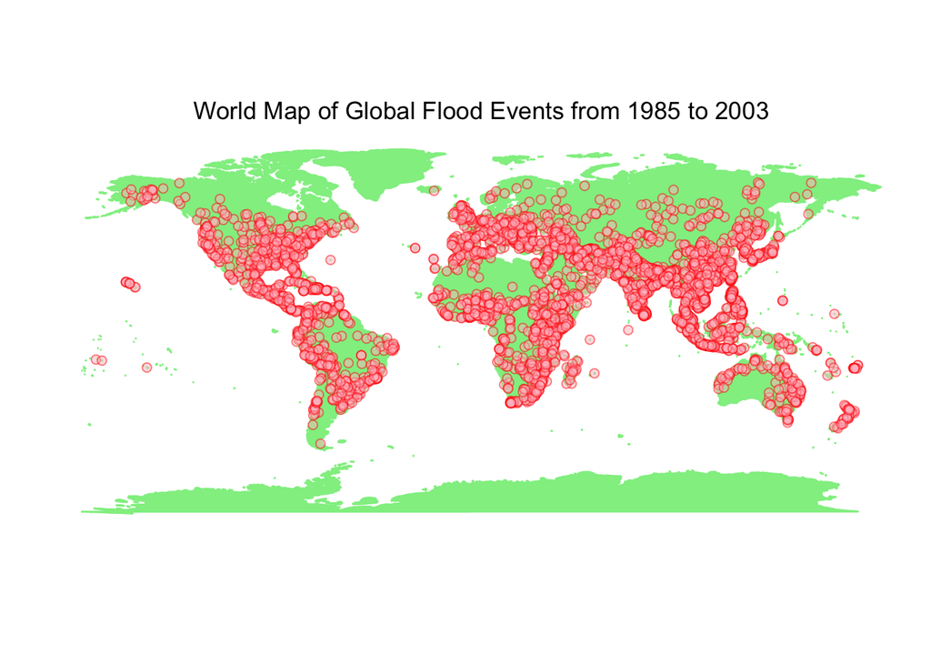

In order to understand the map data we begin to break it down by different categories and look at countries with the largest totals in each.

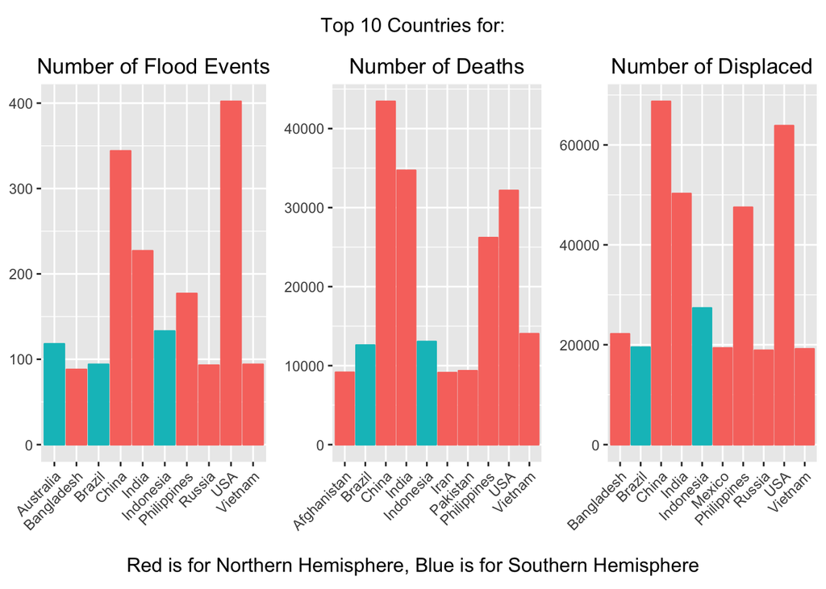

We can see that there are some insights within some of these plots. We can see that there are several countries that appear in all three plots. These are Brazil,China,Indea,Indonesia,Phillippines,USA and Vienam. Seeing some of the more devloped countries such as the USA seems surprising here because of how many flood events actually occur. There could be a difference in reporting here as well, such as the USA has been recording these events longer and therefore has a higher number of events.

Another interesting finding is that Iran, Pakistan and Afghanistan appear in the highest number of deaths but not in the highest number of displaced. Looking deeper into these categoies we find that they just mostlikely missed the top 10.

- Iran we can see that there were 9,107 deaths which also accompanied 10,364 displaced.
- Pakistan we can see that there were 9,346 deaths which also accompanied 14,611 displaced.
- Afghanistan we can see that there were 9,150 deaths which also accompanied 10,931 displaced.

So we can see a positive correlation occuring between the number of Flood Events, Deaths and Displaced.

## Word Cloud

Word clouds were used to try and analyze the differences between the Northern Hemisphere (postive Latitude) and the Sourthern Hemisphere (negative Latitude). We wanted to investigate the column labeled “Notes and Comments”, which included many news articles after cleaning the text the following word clouds were produced.

[figure not shown]

What we can see from these plots is an interesting split between the Northern and Southern hemispheres. “People”, was largely contributed by the Southern Hemisphere and “Flooding” was more attributed to the Northern.

We then continued looking into the differences between northern and southern hemispheres looking at density plots of varios attributes of the flood events.

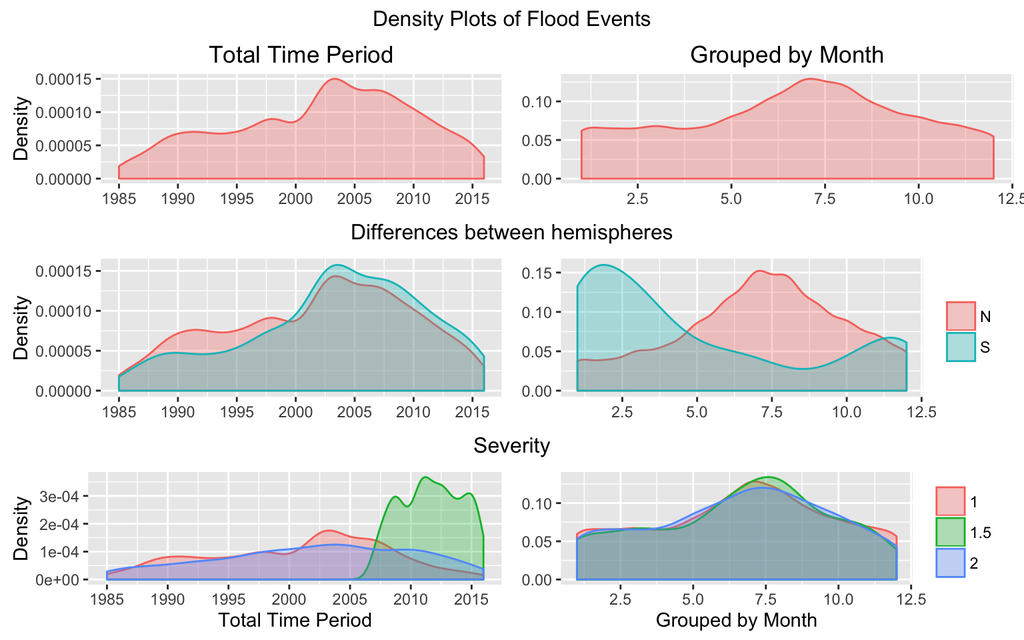

These density plots show us that the total number of flood events occured between the years of 2002 - 2003 by looking at the left column of plots “Total Time Period” Looking at “Differences between Hemispheres” we can actually see this may be mostly contributed by the Southern Hemisphere Countries begining to record their Flood Events along with the countries in the Northern Hemisphere. We can see that from 2002 on the Southern Hemisphere makes up more of the recorded events.

As we look at the right side of the plots “Groupd by Month” we can further see some interesting characteristics. Looking at the upper right plot it would seem that for the world most of the flooding occurs in the 7th month, July. However as we break this down to Northern and Southern Hemispheres we can see that these seasons are opposite for each region. This makes sense because the different hemispheres experience opposite seasons.

Severity per month does not tell us much more additional information, the splits are very similar.